# Executive Summary

After rigorous testing and comparative analysis between advanced machine learning architectures, our team identified a custom-built Convolutional Neural Network (CNN), referred to as Model 1, as the superior solution for this intricate task. Model 1 showcased an impressive low loss of 0.041 and a high accuracy of 0.985, significantly surpassing the pre-trained model, VGG16, which demonstrated a loss of 0.130 and an accuracy of 0.96.

One of the critical advantages of Model 1 was its efficiency in development time, marking a stark contrast against its counterparts. Unlike the pre-trained model, which was time-intensive due to it's complexity and pre-existing structures, Model 1's building process was streamlined, straightforward, and tailored from the ground up, specifically for detecting the Plasmodium parasite in infected cells.

The implementation of Model 1 carries potential for malaria diagnosis globally. Its high accuracy and low loss rate ensure a reliable, rapid identification process, crucial in areas where malaria is prevalent and resources are limited. By significantly reducing the time health professionals spend on microscopic analysis, we enable quicker decision-making, leading to timely, life-saving treatment, reducing the strain on healthcare systems.

Additionally, Model 1's efficient build process translates to cost-effectiveness and ease of adaptation, marking it as a feasible solution for widespread adoption. Its superior performance to the pre-trained alternative underscores its tailored utility for this specific medical need, negating a 'one-size-fits-all' approach in favor of a targeted, efficient diagnostic tool.

With the proof of concept established and the model's efficacy validated, the next strategic step involves developing a comprehensive application accessible to healthcare professionals. This platform will harness the power of Model 1, allowing medical personnel to upload cell images and receive instant, accurate diagnostic information.

The phases of this initiative include field testing, user training, and navigating regulatory landscapes to ensure compliance, data privacy, and seamless integration into existing healthcare infrastructures. Through this innovative approach, we envision a drastic reduction in diagnostic time, an increase in healthcare efficiency, and, most importantly, a robust strategy in the global fight against malaria.

# Problem and Solution Summary

Malaria remains one of the significant causes of morbidity and mortality worldwide, particularly in developing countries. Traditional diagnosis through microscopic examination of blood samples is time-consuming and depends heavily on the expertise of the personnel, making it less scalable and prone to human error.

Implementing a Convolutional Neural Network (CNN), specifically Model 1, automates and enhances the accuracy of malaria diagnosis by identifying infected red blood cells with more precision and speed compared to traditional methods or even other advanced models (like the pre-trained VGG16). By using a more straightforward and more efficient model (loss of 0.041 and accuracy of 0.985), the diagnosis process can be significantly expedited, potentially saving more lives by providing quicker treatment.

> Model 1 Layer Summary: It starts with an input layer specifying an image size of 64x64 pixels with three color channels (RGB). The network consists of three convolutional layers, each followed by a max-pooling layer. The first convolutional layer employs 16 filters, while the second and third layers use 32 and 64 filters, respectively, all activated using Rectified Linear Units (ReLU). Max-pooling layers are applied after each convolution to reduce spatial dimensions. Following the convolutional and max-pooling layers, there's a flattening layer to transition from 2D to 1D data, and two fully connected dense layers. The first dense layer has 256 neurons with ReLU activation, providing high-level feature extraction, and the final dense layer with a single neuron using the sigmoid activation function is responsible for binary classification, producing an output in the range [0, 1]. This model's 98.46% accuracy on the test data demonstrates its effectiveness in correctly detected infected cells with the Plasmodium parasites.

For healthcare providers, particularly in areas where malaria is prevalent, this solution means faster and more accurate diagnoses, efficient allocation of medical resources, timely treatment for patients, and, consequently, a reduction in mortality rates. It can also lead to substantial cost savings in training personnel for microscopic diagnosis, allowing resource allocation to other critical areas.

# Reccommendations for Implementation

## Key Recommendations for Directly using the Model 1:

1. Work closely with health facilities to integrate this solution into their current diagnostic procedures.
2. Although the model reduces the need for highly specialized knowledge, training for users (healthcare professionals) is essential to operate and interpret the model's predictions.
3. Implement regular checks and updates to the model to account for new data and ensure its ongoing effectiveness.

Expected Benefits/Costs:

1. Benefits: Faster and more accurate diagnoses leading to quicker treatments, better patient outcomes, reduced strain on healthcare systems, and lower operational costs due to decreased need for expert human resources.
2. Costs: Initial investment in setting up the infrastructure for the model (hardware/software), training for healthcare professionals, ongoing maintenance, and system updates.

Key Risks and Challenges:

1. Ensuring patient data confidentiality and secure data storage and transmission.
2. CNNs are often considered "black boxes," which might cause resistance from healthcare professionals seeking understandable diagnostic reasoning.
3. Resistance to change or adaptation hurdles within current healthcare diagnostic procedures.

Further Analysis and Associated Problems: Ongoing evaluation of the model's efficacy through tracking its performance with emerging cases and monitoring long-term patient outcomes is essential for determining its real-world impact and precision. Engaging in joint research initiatives with local healthcare entities can improve the model's trustworthiness and facilitate its integration into existing healthcare ecosystems.

Moreover, hurdles in intended deployment regions, such as inconsistent access to stable electricity and internet services, pose significant challenges. It's imperative that the model is versatile, capable of adjusting to diverse data sets reflective of regional differences in malaria strains or prevalent co-morbidities, thereby upholding a standard of fairness and inclusivity in healthcare delivery. Additionally, to expedite the data processing inherent in these advanced diagnostic models, healthcare professionals must have access to adequate computational power, such as GPUs, ensuring the model functions optimally and without prohibitive delays.

**Application**  
Designing and developing an application for Healthcare professionals to upload patient data and immediately returns the results.

Benefits:

1. Less technical training for the healthcare professionals.
2. User-friendly and ease of use.

Costs/Problems:

1. Application usage fees.
2. No direct access to update the Model.

## **Problem Definition**

**The context:** Why is this problem important to solve?

Malaria is a serious and potentially life-threatening disease caused by the Plasmodium parasites. It is primarily transmitted to humans through the bite of infected female Anopheles mosquitoes. Once inside the human body, the parasites multiply in the liver and then infect and damage red blood cells (RBCs) . Malaria can lead to a wide range of symptoms, including high fever, chills, headache, muscle aches, and fatigue. In severe cases, it can cause complications such as organ failure, anemia, and even death.

The Plasmodium parasistes can stay alive for up to a year. It is because of this reason why late detection can consequently cause death. Children under the age of 5 are more susceptible to deadly infection, resulting 67% of the global malaria deaths. Traditional methods of detection require the suspected infected RBCs to be analyzed carefully in a laboratory. This however, is a very time-consuming and likely costly method for determining if the patient may have the parasites. Not to mention this method is prone to human error and accuracy when using the human eye.

An automated system holds promise for the early and accurate detection of malaria. The application of automated classification techniques, incorporating machine learning (ML) and artificial intelligence (AI), consistently achieves higher levels of accuracy when compared to manual approaches. Consequently, it is of great value to explore a method that utilizes deep learning algorithms for the purpose of malaria detection.

**The objectives:** What is the intended goal?  
The goal is to build a machine learning model with Deep Learning Algorithms that can help with early accurate detection of malaria.

**The key questions:** What are the key questions that need to be answered?

1. What deep learning architecture or neural network structure is most suitable for malaria detection, considering the complexities of the data and the need for high accuracy?
2. How can we effectively preprocess and augment the malaria dataset to ensure it is suitable for training a deep learning model?
3. What type of labeled data is required for training and validating the deep learning model, and where can we source this data?
4. Will the model be accurate and fast enough to replace traditional human-eye labarotory detection methods?

**The problem formulation:** What is it that we are trying to solve using data science?  
The problem we aim to address using data science is the development of a highly accurate and efficient deep learning-based system for early detection of malaria. Traditional methods for detecting malaria are often time-consuming, prone to human error, and costly, particularly in regions with limited healthcare resources. By uing the power of deep learning algorithms, we seek to create an automated solution that can rapidly and reliably identify malaria parasites in blood samples. This deep learning model is designed to improve the accuracy, speed, and accessibility of malaria diagnosis, with a strong emphasis on early detection to reduce mortality rates and enhance healthcare outcomes.

## **Data Description**

There are a total of 24,958 train and 2,600 test images (colored) that we have taken from microscopic images. These images are of the following categories:

**Parasitized:** The parasitized cells contain the Plasmodium parasite which causes malaria  
**Uninfected:** The uninfected cells are free of the Plasmodium parasites

### **Mount the Drive**

```python
#Mounting the drive
from google.colab import drive
drive.mount('/content/drive')
```

**Loading libraries**

```python
# importing the libraries needed to load the data

import zipfile
import os
from PIL import Image
import numpy as np
import cv2
from tensorflow.keras.callbacks import EarlyStopping
```

### **Let us load the data**

**Note:**

- You must download the dataset from the link provided on Olympus and upload the same to your Google Drive. Then unzip the folder.

```python
# since it is a zip file, extracting the data from the zip
with zipfile.ZipFile('/content/drive/MyDrive/MIT-course/Capstone/cell_images.zip', 'r') as zip_ref:
    zip_ref.extractall()
```

The extracted folder has different folders for train and test data will contain the different sizes of images for parasitized and uninfected cells within the respective folder name.

The size of all images must be the same and should be converted to 4D arrays so that they can be used as an input for the convolutional neural network. Also, we need to create the labels for both types of images to be able to train and test the model.

Let's do the same for the training data first and then we will use the same code for the test data as well.

```python
#Storing the path for train
train_path = '/content/cell_images/train'
# resizing images
SIZE = 64
train_images = []
train_labels = [] #0 - uninfected, 1 - parasitized


#Storing the path for test
test_path = '/content/cell_images/test'
test_images = []
test_labels = []
```

```python
# Method that will help with training test and train images
def load_images_and_labels(data_path, size):
    images = []
    labels = []

    for folder_name in ['/parasitized/', '/uninfected/']:
        images_path = os.listdir(data_path + folder_name)

        for i, image_name in enumerate(images_path):
            try:
                # image = Image.open(data_path + folder_name + image_name)
                image = cv2.imread(data_path + folder_name + image_name)
                # image = image.resize((size, size))
                image = cv2.resize(image, (size, size))
                images.append(np.array(image))

                if folder_name == '/parasitized/':
                    labels.append(1)
                else:
                    labels.append(0)
            except Exception:
                pass

    return np.array(images), np.array(labels)
```

```python
# Load test data
# Load training data
train_images, train_labels = load_images_and_labels(train_path, SIZE)
test_images, test_labels = load_images_and_labels(test_path, SIZE)
```

### **Check the shape of train and test images**

```python
print(f"Train Images Shape: {train_images.shape}")
print(f"Test Images Shape: {test_images.shape}")
```

```
Train Images Shape: (24958, 64, 64, 3)
Test Images Shape: (2600, 64, 64, 3)
```

### **Check the shape of train and test labels**

```python
print(f"Train Labels Shape: {train_labels.shape}")
print(f"Test Labels Shape: {test_labels.shape}")
```

```
Train Labels Shape: (24958,)
Test Labels Shape: (2600,)
```

#### **Observations and insights: **_****

The train images have 24958 images in total and there are 2600 test images.

### **Check the minimum and maximum range of pixel values for train and test images**

```python
print(f"Train Images - Minimum Pixel Value: {train_images.min()}, Maximum Pixel Value: {train_images.max()}")
print(f"Test Images - Minimum Pixel Value: {test_images.min()}, Maximum Pixel Value: {test_images.max()}")
```

```
Train Images - Minimum Pixel Value: 0, Maximum Pixel Value: 255
Test Images - Minimum Pixel Value: 0, Maximum Pixel Value: 255
```

#### **Observations and insights: **_****

### **Count the number of values in both uninfected and parasitized**

```python
num_uninfected_train = np.sum(train_labels == 0)
print(f"Number of 'uninfected' labels in the train dataset: {num_uninfected_train}")
num_parasitized_train = np.sum(train_labels == 1)
print(f"Number of 'parasitized' labels in the train dataset: {num_parasitized_train}")
```

```
Number of 'uninfected' labels in the train dataset: 12376
Number of 'parasitized' labels in the train dataset: 12582
```

### **Normalize the images**

```python
train_images = train_images / 255.0
test_images  = test_images / 255.0
```

#### **Observations and insights: **_****

### **Plot to check if the data is balanced**

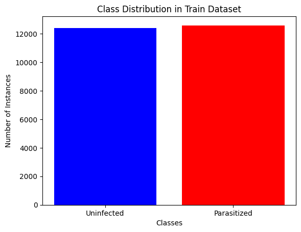

```python
import matplotlib.pyplot as plt

# train_labels is the label array
# Count the number of instances for each class
counts = [np.sum(train_labels == 0), np.sum(train_labels == 1)]

# Labels for the classes
labels = ['Uninfected', 'Parasitized']

# Create a bar plot
plt.bar(labels, counts, color=['blue', 'red'])
plt.xlabel('Classes')
plt.ylabel('Number of Instances')
plt.title('Class Distribution in Train Dataset')
plt.show()
```

#### **Observations and insights: **_****

The data from the graph is very balanced.

### **Data Exploration**

Let's visualize the images from the train data

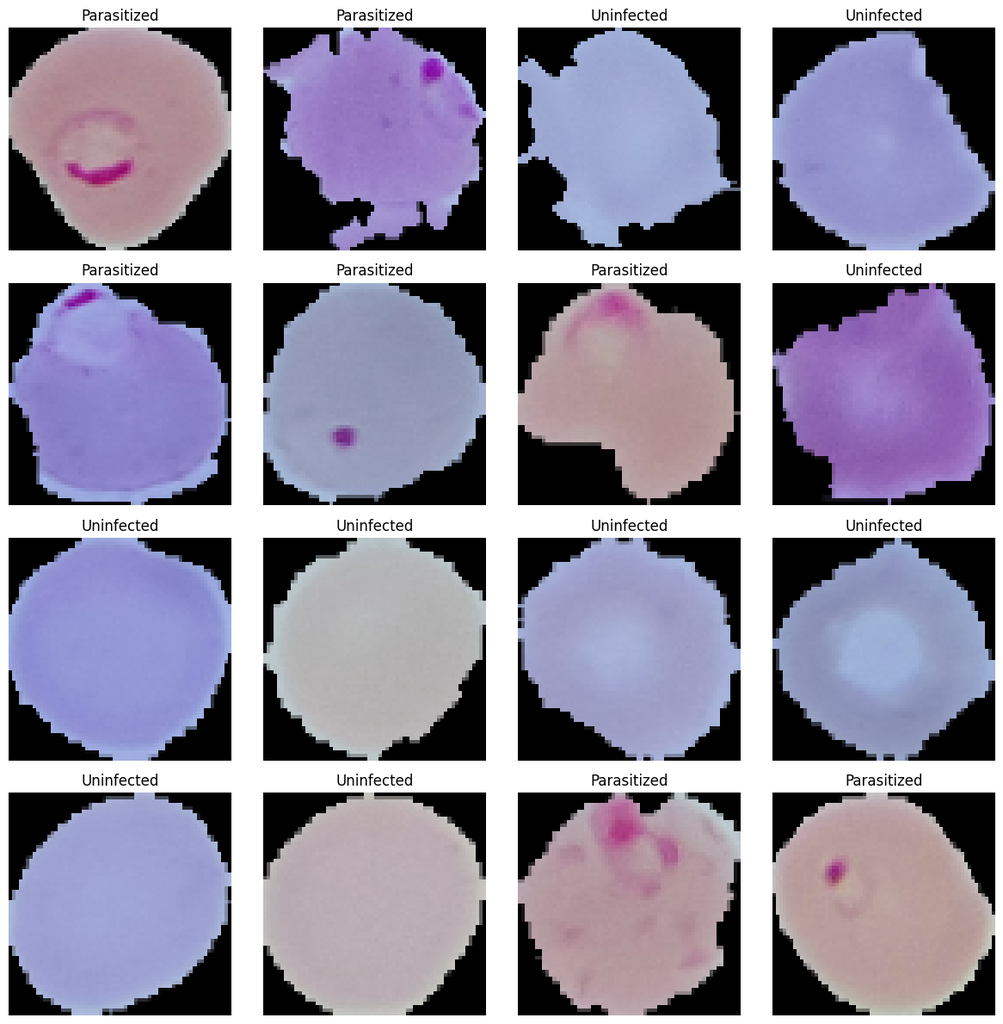

```python
# Define the number of rows and columns for the grid
rows, cols = 4, 4  # You can adjust these values as needed

# Create a figure to display the grid of images
fig, axes = plt.subplots(rows, cols, figsize=(12, 12))

# Choose a set of indices to select images for visualization
indices = np.random.choice(len(train_images), size=rows * cols, replace=False)

# Loop through the selected indices and display images
for i, ax in enumerate(axes.ravel()):
    index = indices[i]
    image = train_images[index]
    label = "Parasitized" if train_labels[index] == 1 else "Uninfected"

    # Display the image
    ax.imshow(image)
    ax.set_title(label)
    ax.axis('off')

# Adjust spacing between subplots
plt.tight_layout()
plt.show()
```

#### **Observations and insights: **_****

> Parasitized images have spots of color.

### **Visualize the images with subplot(6, 6) and figsize = (12, 12)**

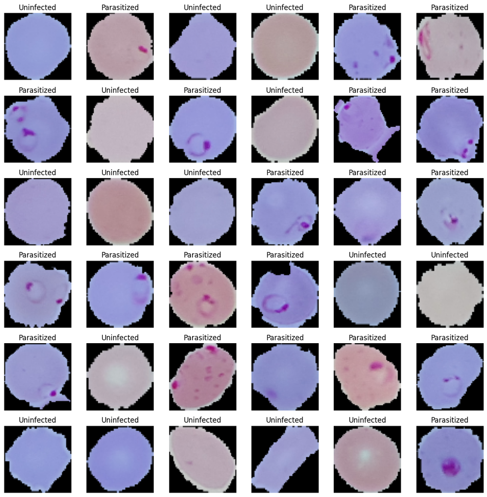

```python
rows, cols = 6, 6
fig, axes = plt.subplots(rows, cols, figsize=(12, 12))

# Choose a set of indices to select images for visualization
indices = np.random.choice(len(train_images), size=rows * cols, replace=False)

# Loop through the selected indices and display images
for i, ax in enumerate(axes.ravel()):
    index = indices[i]
    image = train_images[index]
    label = "Parasitized" if train_labels[index] == 1 else "Uninfected"

    # Display the image
    ax.imshow(image)
    ax.set_title(label)
    ax.axis('off')

# Adjust spacing between subplots
plt.tight_layout()
plt.show()
```

#### **Observations and insights:**

### **Plotting the mean images for parasitized and uninfected**

```python
def find_mean_img(full_mat, title):
    # Calculate the average
    # mean_img = np.mean(full_mat, axis = 0)
    mean_img = full_mat.mean(axis=0).astype(np.uint8)
    print(mean_img.shape)

    # Reshape it back to a matrix
    plt.imshow(mean_img)

    plt.title(f'Average {title}')

    plt.axis('off')

    plt.show()

    return mean_img
```

**Mean image for parasitized**

```
(64, 64, 3)
```

[figure not shown]

```python
mean_parasitized = find_mean_img(train_images[train_labels == 1], "Parasitized")
```

**Mean image for uninfected**

```
(64, 64, 3)
```

[figure not shown]

```python
mean_parasitized = find_mean_img(train_images[train_labels == 1], "Uninfected")
```

### **Converting RGB to HSV of Images using OpenCV**

### **Converting the train data**

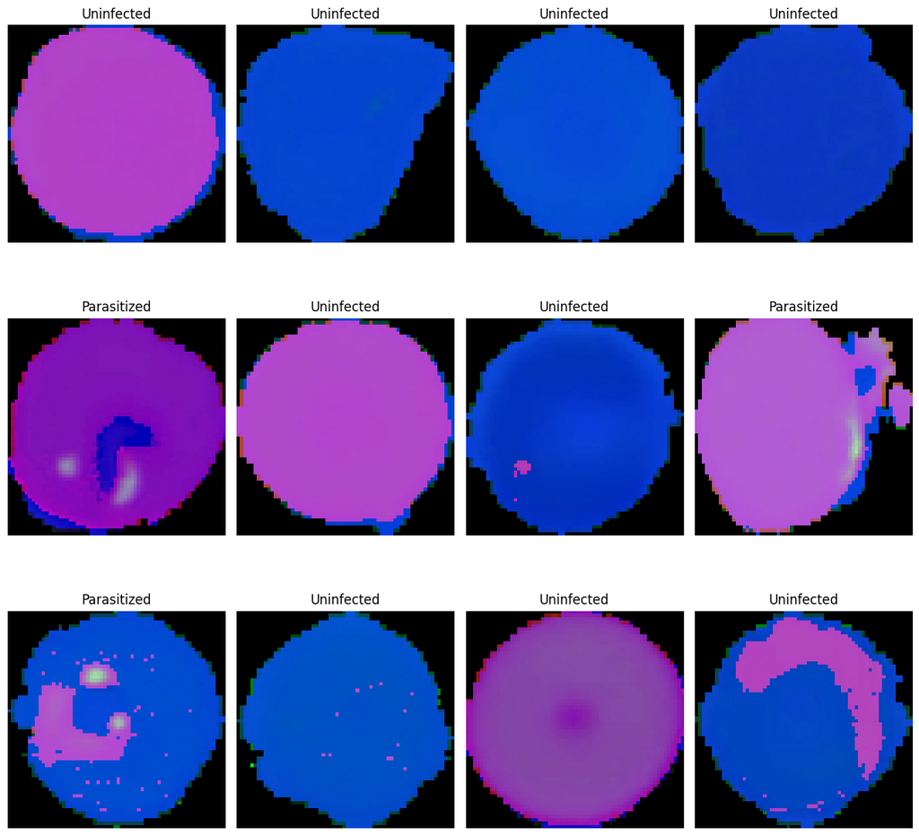

```python
hsv_train_images = []
hsv_labels = []

ids = np.random.randint(0, len(train_images), 12)
for _id in ids:
  img = train_images[_id]
  img = cv2.cvtColor(img, cv2.COLOR_BGR2HSV)

  hsv_train_images.append(img)
  hsv_labels.append(train_labels[_id])

rows, cols = 3,4
fig, axes = plt.subplots(rows, cols, figsize=(12, 12))

# Loop through the selected indices and display images
for i, ax in enumerate(axes.ravel()):
    image = hsv_train_images[i]
    label = "Parasitized" if hsv_labels[i] == 1 else "Uninfected"

    # Display the image
    ax.imshow(image)
    ax.set_title(label)
    ax.axis('off')

# Adjust spacing between subplots
plt.tight_layout()
plt.show()
```

### **Converting the test data**

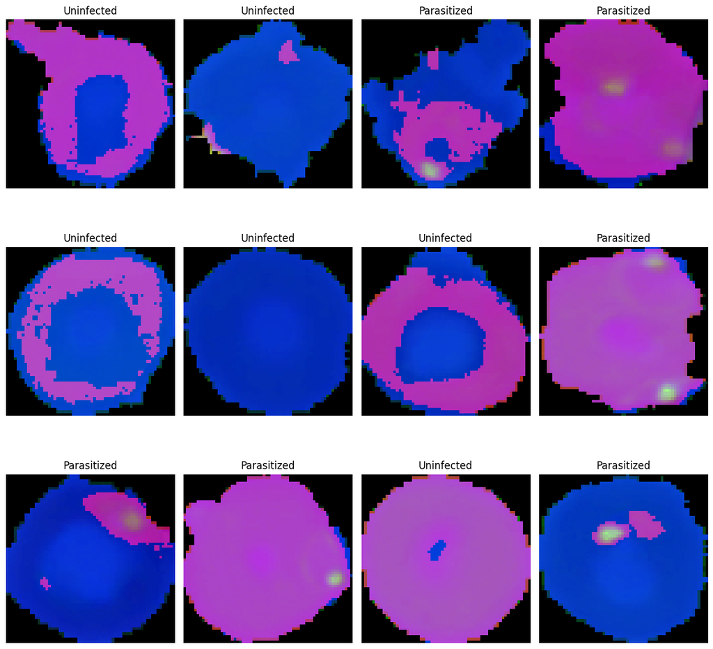

```python
hsv_test_images = []
hsv_test_labels = []

ids = np.random.randint(0, len(test_images), 12)
for _id in ids:
  img = test_images[_id]
  img = cv2.cvtColor(img, cv2.COLOR_BGR2HSV)

  hsv_test_images.append(img)
  hsv_test_labels.append(test_labels[_id])

rows, cols = 3,4
fig, axes = plt.subplots(rows, cols, figsize=(12, 12))

# Loop through the selected indices and display images
for i, ax in enumerate(axes.ravel()):
    image = hsv_test_images[i]
    label = "Parasitized" if hsv_test_labels[i] == 1 else "Uninfected"

    # Display the image
    ax.imshow(image)
    ax.set_title(label)
    ax.axis('off')

# Adjust spacing between subplots
plt.tight_layout()
plt.show()
```

#### **Observations and insights: **_****

The HSV images have green spots that show infected cells.

### **Processing Images using Gaussian Blurring**

### **Gaussian Blurring on train data**

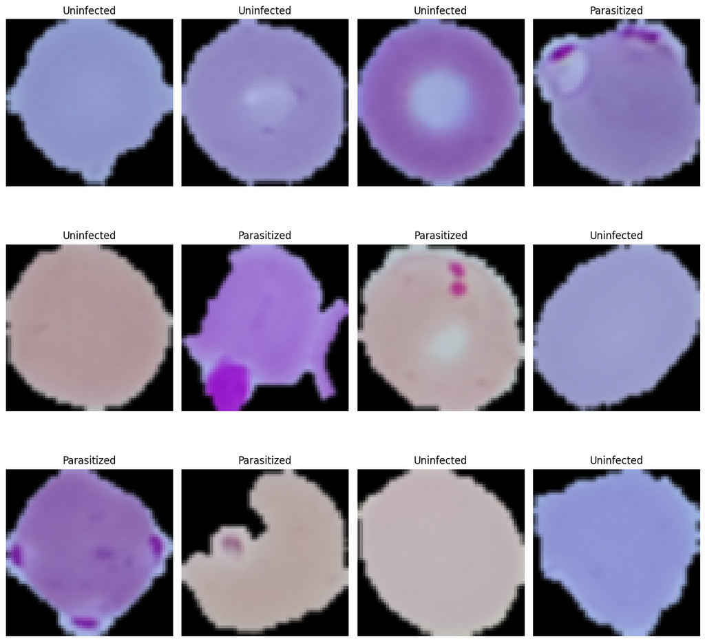

```python
gauss_train_images = []
gauss_labels = []

ids = np.random.randint(0, len(train_images), 12)
for _id in ids:
  img = train_images[_id]
  img = cv2.GaussianBlur(img, (3,3), 0)

  gauss_train_images.append(img)
  gauss_labels.append(train_labels[_id])

rows, cols = 3,4
fig, axes = plt.subplots(rows, cols, figsize=(12, 12))

# Loop through the selected indices and display images
for i, ax in enumerate(axes.ravel()):
    image = gauss_train_images[i]
    label = "Parasitized" if gauss_labels[i] == 1 else "Uninfected"

    # Display the image
    ax.imshow(image)
    ax.set_title(label)
    ax.axis('off')

# Adjust spacing between subplots
plt.tight_layout()
plt.show()
```

### **Gaussian Blurring on test data**

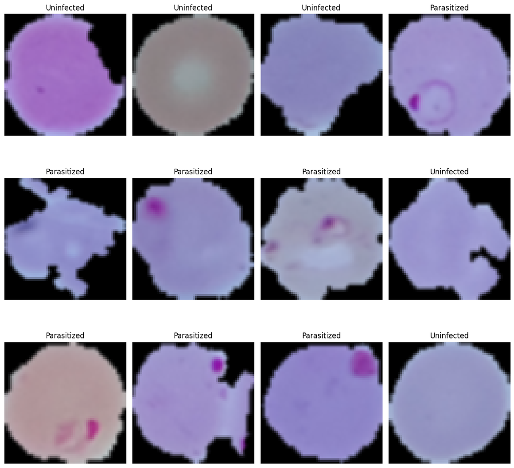

```python
gauss_test_images = []
gauss_test_labels = []

ids = np.random.randint(0, len(test_images), 12)
for _id in ids:
  img = test_images[_id]
  img = cv2.GaussianBlur(img, (3,3), 0)

  gauss_test_images.append(img)
  gauss_test_labels.append(test_labels[_id])

rows, cols = 3,4
fig, axes = plt.subplots(rows, cols, figsize=(12, 12))

# Loop through the selected indices and display images
for i, ax in enumerate(axes.ravel()):
    image = gauss_test_images[i]
    label = "Parasitized" if gauss_test_labels[i] == 1 else "Uninfected"

    # Display the image
    ax.imshow(image)
    ax.set_title(label)
    ax.axis('off')

# Adjust spacing between subplots
plt.tight_layout()
plt.show()
```

#### **Observations and insights: **_****

**Think About It:** Would blurring help us for this problem statement in any way? What else can we try?

Blurring the images makes it difficult to visualize.

No blurring would not help. It will remove necessary fine detail in the image that aids in Malaria detection or parasite detection. We can try using Convolutional Neural Networks.

## **Model Building**

### **Base Model**

**Note:** The Base Model has been fully built and evaluated with all outputs shown to give an idea about the process of the creation and evaluation of the performance of a CNN architecture. A similar process can be followed in iterating to build better-performing CNN architectures.

### **Importing the required libraries for building and training our Model**

```python
from tensorflow.keras import Sequential
from tensorflow.keras.layers import Conv2D, MaxPool2D, Dropout, Dense, Flatten
from keras.preprocessing.image import ImageDataGenerator
from sklearn.model_selection import train_test_split
import numpy as np
from sklearn.metrics import confusion_matrix
from sklearn.metrics import confusion_matrix
import numpy as np
import shutil
import os
import glob
```

```python
image_paths = glob.glob("/content/cell_images/train/*/*.png")
labels = list(map(lambda x: x.split('/')[-2], image_paths))
```

```python
# The split is performed with a test/validation size of 20% of the data, and it uses stratification to maintain the class distribution in the split.
train_image_paths, val_image_paths = train_test_split(image_paths, test_size=0.2, stratify=labels)
```

```python
TRAIN_IMAGE_FOLDER = "training_data"
VALIDATION_IMAGE_FOLDER = "validation_data"
os.makedirs(f"/content/cell_images/{TRAIN_IMAGE_FOLDER}/parasitized", exist_ok=True) #making directories
os.makedirs(f"/content/cell_images/{TRAIN_IMAGE_FOLDER}/uninfected", exist_ok=True)

os.makedirs(f"/content/cell_images/{VALIDATION_IMAGE_FOLDER}/parasitized", exist_ok=True)
os.makedirs(f"/content/cell_images/{VALIDATION_IMAGE_FOLDER}/uninfected", exist_ok=True)

for img_path in train_image_paths:
  shutil.move(img_path, img_path.replace("train", "training_data")) #renaming

for img_path in val_image_paths:
  shutil.move(img_path, img_path.replace("train", "validation_data"))
```

```python
# data is only rescaled to have pixel values between 0 and 1
datagen = ImageDataGenerator(rescale=1./255,
                                      # zoom_range=0.2,
                                      # horizontal_flip=True,
                                      # vertical_flip=True,
                                      # width_shift_range=0.2,
                                      # height_shift_range=0.2,
                                      # validation_split=0.2
                                      )
train_data = datagen.flow_from_directory(
    f"/content/cell_images/{TRAIN_IMAGE_FOLDER}",
    target_size=(64,64),
    batch_size=128,
    class_mode = 'binary',
)

validation_data = datagen.flow_from_directory(
    f"/content/cell_images/{VALIDATION_IMAGE_FOLDER}",
    target_size=(64,64),
    batch_size=128,
    class_mode = 'binary',
    shuffle=False
)

test_data = datagen.flow_from_directory(
    "/content/cell_images/test",
    target_size=(64,64),
    batch_size=128,
    class_mode = 'binary',
    shuffle=False
)
```

```
Found 19966 images belonging to 2 classes.
Found 4992 images belonging to 2 classes.
Found 2600 images belonging to 2 classes.
```

### **Building the model**

```python
model=Sequential([
    Conv2D(16,(3,3),input_shape=(64,64,3),activation='relu'),
    MaxPool2D(2,2),

    Conv2D(32,(3,3),activation='relu'),
    MaxPool2D(2,2),

    # Conv2D(64,(3,3),activation='relu'),
    # MaxPool2D(2,2),


    Flatten(),
    # Dense(256,activation='relu'),
    Dense(1,activation='sigmoid')

])
```

### **Compiling the model**

```python
model.compile(loss='binary_crossentropy',
              optimizer='Adam',
              metrics=['accuracy'])
```

```python
early_stopping = EarlyStopping(monitor='val_loss', patience=5, verbose=1, restore_best_weights=True)
```

**Fit and train our Model**

```python
history = model.fit_generator(
    train_data,
    validation_data = validation_data,
    epochs = 20,
    verbose = 1,
    callbacks=[early_stopping]
)
```

### **Evaluating the model on test data**

```python
evaluation = model.evaluate_generator(test_data)

loss = evaluation[0]
accuracy = evaluation[1]
print(f'Loss: {loss}, Accuracy: {accuracy}')
```

```
Loss: 0.09715034067630768, Accuracy: 0.9711538553237915
```

**Callbacks**

```python
# Generate predictions using the model and the data generator
predictions = model.predict_generator(test_data)

# Convert predicted probabilities to binary class labels (0 or 1)
predicted_labels = np.round(predictions)

# Obtain the true binary labels from the data generator
true_labels = test_data.classes

# Calculate the confusion matrix
confusion = confusion_matrix(true_labels, predicted_labels)
print(confusion)
```

```
[[1241   59]
 [  16 1284]]
```

**Plotting the train and validation curves**

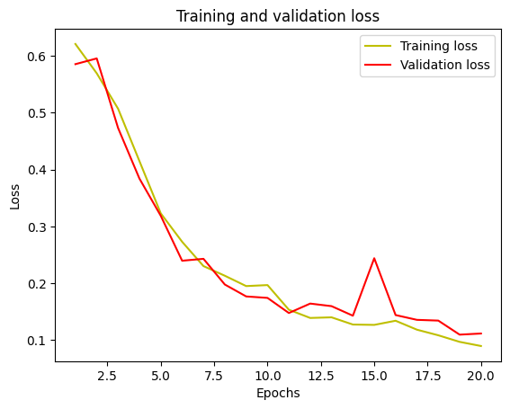

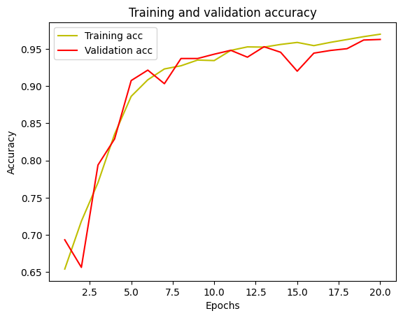

```python
loss = history.history['loss']
val_loss = history.history['val_loss']
epochs = range(1, len(loss) + 1)
plt.plot(epochs, loss, 'y', label='Training loss')
plt.plot(epochs, val_loss, 'r', label='Validation loss')
plt.title('Training and validation loss')
plt.xlabel('Epochs')
plt.ylabel('Loss')
plt.legend()
plt.show()


acc = history.history['accuracy']
val_acc = history.history['val_accuracy']
plt.plot(epochs, acc, 'y', label='Training acc')
plt.plot(epochs, val_acc, 'r', label='Validation acc')
plt.title('Training and validation accuracy')
plt.xlabel('Epochs')
plt.ylabel('Accuracy')
plt.legend()
plt.show()
```

So now let's try to build another model with few more add on layers and try to check if we can try to improve the model. Therefore try to build a model by adding few layers if required and altering the activation functions.

### **Model 1: Final Model**

#### **Trying to improve the performance of our model by adding new layers**

### **Building the Model**

```python
model=Sequential([
    Conv2D(16,(3,3),input_shape=(64,64,3),activation='relu'),
    MaxPool2D(2,2),

    Conv2D(32,(3,3),activation='relu'),
    MaxPool2D(2,2),

    Conv2D(64,(3,3),activation='relu'),
    MaxPool2D(2,2),


    Flatten(),
    Dense(256,activation='relu'),
    Dense(1,activation='sigmoid')

])
```

### **Compiling the model**

```python
model.compile(loss='binary_crossentropy',
              optimizer='Adam',
              metrics=['accuracy'])
```

**Using Callbacks**

```python
early_stopping = EarlyStopping(monitor='val_loss', patience=5, verbose=1, restore_best_weights=True)
```

**Fit and Train the model**

```python
history = model.fit_generator(
    train_data,
    validation_data = validation_data,
    epochs = 20,
    verbose = 1, callbacks=[early_stopping]
)
```

```
Epoch 13: early stopping
```

### **Evaluating the model**

```python
evaluation = model.evaluate_generator(test_data)

loss = evaluation[0]
accuracy = evaluation[1]
print(f'Loss: {loss}, Accuracy: {accuracy}')
```

```
Loss: 0.04183337464928627, Accuracy: 0.9846153855323792
```

**Callbacks**

```python
# Generate predictions using the model and the data generator
predictions = model.predict_generator(test_data)

# Convert predicted probabilities to binary class labels (0 or 1)
predicted_labels = np.round(predictions)

# Obtain the true binary labels from the data generator
true_labels = test_data.classes

# Calculate the confusion matrix
confusion = confusion_matrix(true_labels, predicted_labels)
print(confusion)
```

```
[[1276   24]
 [  16 1284]]
```

**Plotting the train and the validation curves**

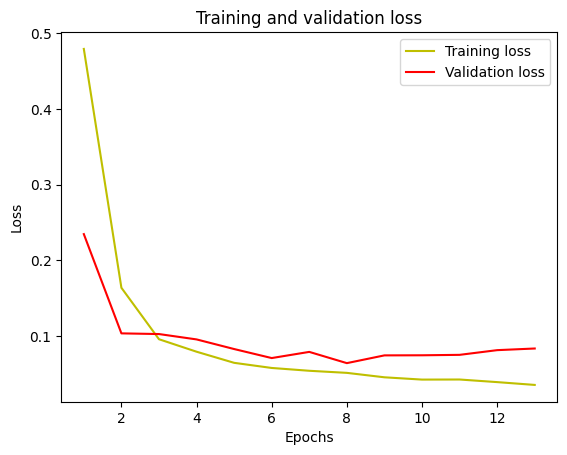

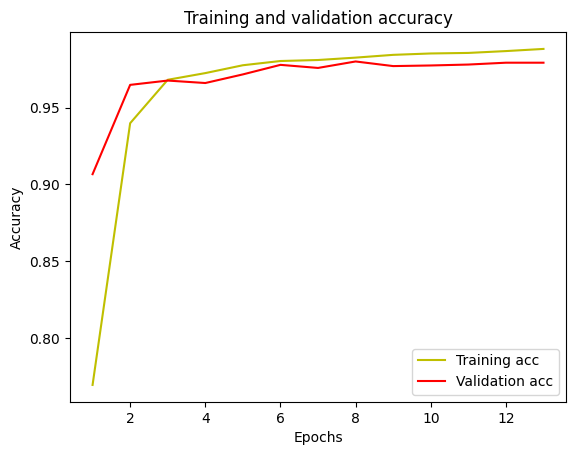

```python
loss = history.history['loss']
val_loss = history.history['val_loss']
epochs = range(1, len(loss) + 1)
plt.plot(epochs, loss, 'y', label='Training loss')
plt.plot(epochs, val_loss, 'r', label='Validation loss')
plt.title('Training and validation loss')
plt.xlabel('Epochs')
plt.ylabel('Loss')
plt.legend()
plt.show()


acc = history.history['accuracy']
val_acc = history.history['val_accuracy']
plt.plot(epochs, acc, 'y', label='Training acc')
plt.plot(epochs, val_acc, 'r', label='Validation acc')
plt.title('Training and validation accuracy')
plt.xlabel('Epochs')
plt.ylabel('Accuracy')
plt.legend()
plt.show()
```

### **Think about it:**

Now let's build a model with LeakyRelu as the activation function

- Can the model performance be improved if we change our activation function to LeakyRelu?
- Can BatchNormalization improve our model?

Let us try to build a model using BatchNormalization and using LeakyRelu as our activation function.

### **Model 2 with Batch Normalization**

```python
import tensorflow as tf
```

### **Building the Model**

```python
model=Sequential([
    Conv2D(16,(3,3),input_shape=(64,64,3),activation=tf.keras.layers.LeakyReLU(alpha=0.2)),
    MaxPool2D(2,2),

    Conv2D(32,(3,3),activation=tf.keras.layers.LeakyReLU(alpha=0.2)),
    MaxPool2D(2,2),

    Conv2D(64,(3,3),activation=tf.keras.layers.LeakyReLU(alpha=0.2)),
    MaxPool2D(2,2),


    Flatten(),
    Dense(256,activation=tf.keras.layers.LeakyReLU(alpha=0.2)),
    tf.keras.layers.BatchNormalization(),
    Dense(1,activation='sigmoid')

])
```

### **Compiling the model**

```python
model.compile(loss='binary_crossentropy',
              optimizer='Adam',
              metrics=['accuracy'])
```

**Using callbacks**

```python
early_stopping = EarlyStopping(monitor='val_loss', patience=5, verbose=1, restore_best_weights=True)
```

**Fit and train the model**

```python
history = model.fit_generator(
    train_data,
    validation_data = validation_data,
    epochs = 20,
    verbose = 1, callbacks=[early_stopping]
)
```

```
Epoch 12: early stopping
```

**Plotting the train and validation accuracy**

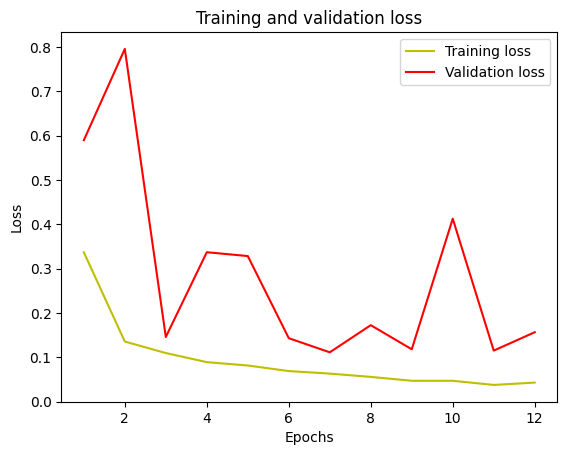

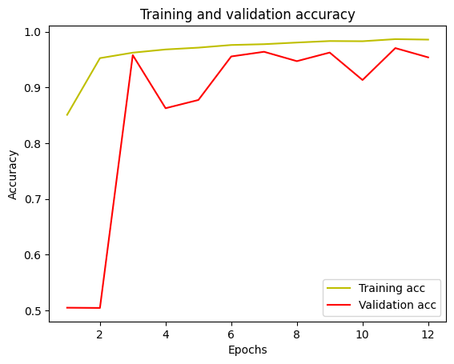

```python
loss = history.history['loss']
val_loss = history.history['val_loss']
epochs = range(1, len(loss) + 1)
plt.plot(epochs, loss, 'y', label='Training loss')
plt.plot(epochs, val_loss, 'r', label='Validation loss')
plt.title('Training and validation loss')
plt.xlabel('Epochs')
plt.ylabel('Loss')
plt.legend()
plt.show()


acc = history.history['accuracy']
val_acc = history.history['val_accuracy']
plt.plot(epochs, acc, 'y', label='Training acc')
plt.plot(epochs, val_acc, 'r', label='Validation acc')
plt.title('Training and validation accuracy')
plt.xlabel('Epochs')
plt.ylabel('Accuracy')
plt.legend()
plt.show()
```

### **Evaluating the model**

```python
evaluation = model.evaluate_generator(test_data)

loss = evaluation[0]
accuracy = evaluation[1]
print(f'Loss: {loss}, Accuracy: {accuracy}')
```

```
Loss: 0.07963817566633224, Accuracy: 0.9723076820373535
```

**Callbacks**

```python
# Generate predictions using the model and the data generator
predictions = model.predict_generator(test_data)

# Convert predicted probabilities to binary class labels (0 or 1)
predicted_labels = np.round(predictions)

# Obtain the true binary labels from the data generator
true_labels = test_data.classes

# Calculate the confusion matrix
confusion = confusion_matrix(true_labels, predicted_labels)
print(confusion)
```

```
[[1244   56]
 [  16 1284]]
```

#### **Observations and insights: *__***

Batch Normalization didn't improve the Model 1 from before. Although it has high accuracy of 97%

### **Think About It :**

- Can we improve the model with Image Data Augmentation?
- References to image data augmentation can be seen below:
  - [Image Augmentation for Computer Vision](https://www.mygreatlearning.com/blog/understanding-data-augmentation/)
  - [How to Configure Image Data Augmentation in Keras?](https://machinelearningmastery.com/how-to-configure-image-data-augmentation-when-training-deep-learning-neural-networks/)

### **Model 3 with Data Augmentation**

```python
datagen = ImageDataGenerator(rescale=1./255,
                                      zoom_range=0.2,
                                      horizontal_flip=True,
                                      vertical_flip=True,
                                      width_shift_range=0.2,
                                      height_shift_range=0.2,
                                      validation_split=0.2
                                      )
train_data = datagen.flow_from_directory(
    f"/content/cell_images/{TRAIN_IMAGE_FOLDER}",
    target_size=(64,64),
    batch_size=128,
    class_mode = 'binary',
)

validation_data = datagen.flow_from_directory(
    f"/content/cell_images/{VALIDATION_IMAGE_FOLDER}",
    target_size=(64,64),
    batch_size=128,
    class_mode = 'binary',
)

test_data = datagen.flow_from_directory(
    "/content/cell_images/test",
    target_size=(64,64),
    batch_size=128,
    class_mode = 'binary',
)
```

```
Found 19966 images belonging to 2 classes.
Found 4992 images belonging to 2 classes.
Found 2600 images belonging to 2 classes.
```

### **Building the Model**

```python
model=Sequential([
    Conv2D(16,(3,3),input_shape=(64,64,3),activation=tf.keras.layers.LeakyReLU(alpha=0.2)),
    MaxPool2D(2,2),

    Conv2D(32,(3,3),activation=tf.keras.layers.LeakyReLU(alpha=0.2)),
    MaxPool2D(2,2),

    Conv2D(64,(3,3),activation=tf.keras.layers.LeakyReLU(alpha=0.2)),
    MaxPool2D(2,2),


    Flatten(),
    Dense(256,activation=tf.keras.layers.LeakyReLU(alpha=0.2)),
    tf.keras.layers.BatchNormalization(),
    Dense(1,activation='sigmoid')

])

model.compile(loss='binary_crossentropy',
              optimizer='Adam',
              metrics=['accuracy'])
```

**Using Callbacks**

```python
early_stopping = EarlyStopping(monitor='val_loss', patience=5, verbose=1, restore_best_weights=True)
```

**Fit and Train the model**

```python
history = model.fit_generator(
    train_data,
    validation_data = validation_data,
    epochs = 20,
    verbose = 1, callbacks=[early_stopping]
)
```

```
Epoch 18: early stopping
```

### **Evaluating the model**

```python
evaluation = model.evaluate_generator(test_data)

loss = evaluation[0]
accuracy = evaluation[1]
print(f'Loss: {loss}, Accuracy: {accuracy}')
```

```
Loss: 0.1382800042629242, Accuracy: 0.9534615278244019
```

**Callback**

```python
# Generate predictions using the model and the data generator
predictions = model.predict_generator(test_data)

# Convert predicted probabilities to binary class labels (0 or 1)
predicted_labels = np.round(predictions)

# Obtain the true binary labels from the data generator
true_labels = test_data.classes

# Calculate the confusion matrix
confusion = confusion_matrix(true_labels, predicted_labels)
print(confusion)
```

```
[[619 681]
 [650 650]]
```

**Plot the train and validation accuracy**

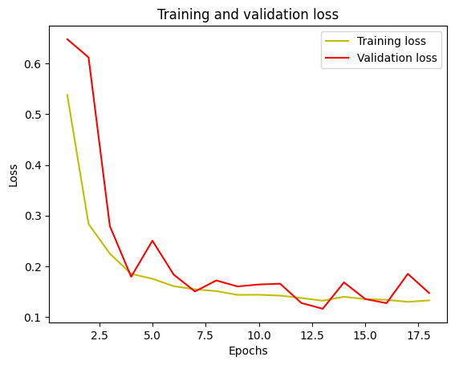

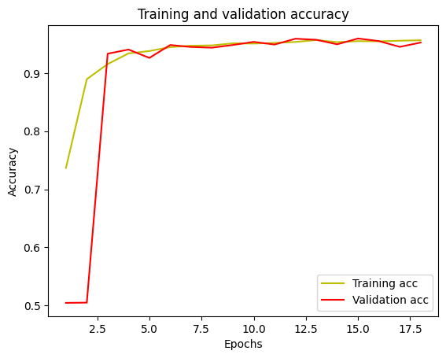

```python
loss = history.history['loss']
val_loss = history.history['val_loss']
epochs = range(1, len(loss) + 1)
plt.plot(epochs, loss, 'y', label='Training loss')
plt.plot(epochs, val_loss, 'r', label='Validation loss')
plt.title('Training and validation loss')
plt.xlabel('Epochs')
plt.ylabel('Loss')
plt.legend()
plt.show()


acc = history.history['accuracy']
val_acc = history.history['val_accuracy']
plt.plot(epochs, acc, 'y', label='Training acc')
plt.plot(epochs, val_acc, 'r', label='Validation acc')
plt.title('Training and validation accuracy')
plt.xlabel('Epochs')
plt.ylabel('Accuracy')
plt.legend()
plt.show()
```

**Now, let us try to use a pretrained model like VGG16 and check how it performs on our data.**

### **Pre-trained model (VGG16)**

- Import VGG16 network upto any layer you choose
- Add Fully Connected Layers on top of it

```python
from tensorflow.keras.applications import VGG16
from tensorflow.keras.models import Sequential
```

```python
vgg_base = VGG16(include_top=False, input_shape=(64, 64, 3))

head_model = Sequential()
head_model.add(Flatten(input_shape=vgg_base.output_shape[1:]))
head_model.add(Dense(128, activation='relu'))
head_model.add(Dropout(0.5))
head_model.add(Dense(1, activation='sigmoid'))  # For binary classification, change output units accordingly

# Combine the VGG base model and the custom top model
model = Sequential()
model.add(vgg_base)
model.add(head_model)

print(model.summary())
```

```
Downloading data from https://storage.googleapis.com/tensorflow/keras-applications/vgg16/vgg16_weights_tf_dim_ordering_tf_kernels_notop.h5
Model: "sequential_5"
_________________________________________________________________
 Layer (type)                Output Shape              Param #
=================================================================
 vgg16 (Functional)          (None, 2, 2, 512)         14714688

 sequential_4 (Sequential)   (None, 1)                 262401

=================================================================
Total params: 14977089 (57.13 MB)
Trainable params: 14977089 (57.13 MB)
Non-trainable params: 0 (0.00 Byte)
_________________________________________________________________
None
```

### **Compiling the model**

```python
model.compile(loss='binary_crossentropy',
              optimizer='Adam',
              metrics=['accuracy'])
```

**using callbacks**

```python
early_stopping = EarlyStopping(monitor='val_loss', patience=5, verbose=1, restore_best_weights=True)
```

**Fit and Train the model**

```python
history = model.fit_generator(
    train_data,
    validation_data = validation_data,
    epochs = 20,
    verbose = 1, callbacks=[early_stopping]
)
```

```
Epoch 7: early stopping
```

**Plot the train and validation accuracy**

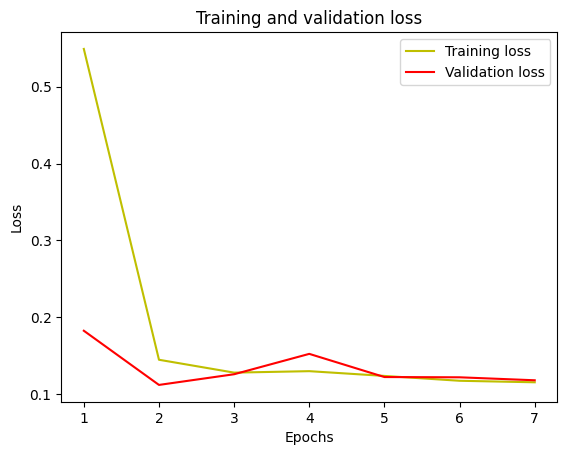

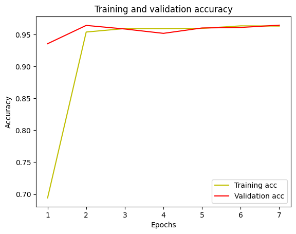

```python
loss = history.history['loss']
val_loss = history.history['val_loss']
epochs = range(1, len(loss) + 1)
plt.plot(epochs, loss, 'y', label='Training loss')
plt.plot(epochs, val_loss, 'r', label='Validation loss')
plt.title('Training and validation loss')
plt.xlabel('Epochs')
plt.ylabel('Loss')
plt.legend()
plt.show()


acc = history.history['accuracy']
val_acc = history.history['val_accuracy']
plt.plot(epochs, acc, 'y', label='Training acc')
plt.plot(epochs, val_acc, 'r', label='Validation acc')
plt.title('Training and validation accuracy')
plt.xlabel('Epochs')
plt.ylabel('Accuracy')
plt.legend()
plt.show()
```

### **Observations and insights: **_****

Data Augumentation Model performed the worse out of all of the models used.

- What can be observed from the validation and train curves?  
  The validation curves and train curves accuracy start to match after 4 epochs.

### **Evaluating the model**

```python
evaluation = model.evaluate_generator(test_data)

loss = evaluation[0]
accuracy = evaluation[1]
print(f'Loss: {loss}, Accuracy: {accuracy}')
```

```
Loss: 0.1301223337650299, Accuracy: 0.9599999785423279
```

**Callback**

```python
# Generate predictions using the model and the data generator
predictions = model.predict_generator(test_data)

# Convert predicted probabilities to binary class labels (0 or 1)
predicted_labels = np.round(predictions)

# Obtain the true binary labels from the data generator
true_labels = test_data.classes

# Calculate the confusion matrix
confusion = confusion_matrix(true_labels, predicted_labels)
print(confusion)
```

```
[[608 692]
 [652 648]]
```

### **Think about it:**

- What observations and insights can be drawn from the confusion matrix and classification report?
  - We can get insight about Accuracy, Precision, Recall and F1-Score
- Choose the model with the best accuracy scores from all the above models and save it as a final model.

#### **Observations and Conclusions drawn from the final model:**

Final Model: Model 1

**Improvements that can be done:**

- Can the model performance be improved using other pre-trained models or different CNN architecture?
  - I think the answer is yes, because this dataset is not too unique, so it's can improved by transferlearning. Current model doesn't seems to be overfit, so stronger model can improve the result
- You can try to build a model using these HSV images and compare them with your other models.

#### **Proposal for the final solution design**:

```python
#exporting to html
%%shell
jupyter nbconvert --to html /content/Full_Code_Malaria_Detection_Wilkins_El.ipynb
```

```
[NbConvertApp] Converting notebook /content/Full_Code_Malaria_Detection_Wilkins_El.ipynb to html
[NbConvertApp] Writing 2889922 bytes to /content/Full_Code_Malaria_Detection_Wilkins_El.html
```